# Terns mass-decline summary: migrants vs. breeders, spring, summer, within-season, chicks

Consolidates issues #5, #6, #7, #8, #9, #10 - normalized mass only

2026-09-23

# 1 Background

This report pulls together every mass-related result from issues #5, #6, #7, #8, #9 and #10 into one place, answering five specific questions Inbal asked to have summarized together. **Only the two wing-normalized mass metrics are used throughout** (simple ratio `Weight/Wing`, and SMI - scaled mass index, Peig & Green 2009) - raw mass is not shown in any table or plot here, even where it was the headline metric in the original issue, because raw mass conflates body condition with body size and normalizing is the better-supported approach (see issue #6’s background for the methods discussion). Every plot is followed by its sample-size table and its significance-test table, and every trend section ends with a test of whether the most recent year (2026, or the most recent year with data where 2026 is missing) differs from what the historical trend would predict.

**The five questions**, each becomes one section below:

1. Is there a mass difference between the breeding population and the passage/migrant population, and does that differ by species? (`Spring: breeders vs. migrants`)
2. Does breeding-population adult mass decline over the years in spring? (`Spring: breeder mass over years`)
3. Does adult mass change over the years in summer? (`Summer: adult mass over years`)
4. Within a season, does mass change, and is that pattern itself changing over the years or in the most recent year(s)? (`Within-season trajectory`)
5. Does chick mass decline over the years? (`Chicks: mass over years`)

# 2 Data loading

```r
raw_dir <- "../data_raw"
if (!dir.exists(raw_dir)) raw_dir <- "data_raw"
stopifnot(dir.exists(raw_dir))

proc_dir <- "../data_processed"
if (!dir.exists(proc_dir)) proc_dir <- "data_processed"

out_dir <- "../output"
if (!dir.exists(out_dir)) out_dir <- "output"

docs_dir <- "../docs"
if (!dir.exists(docs_dir)) docs_dir <- "docs"

ringing_path <- file.path(raw_dir, "ringing_data_raw.xlsx")
stopifnot(file.exists(ringing_path))

col_names_47 <- c(
  "CR1","RingReplace","Rec","RingPrefix","RingNum","Species","Sex","Age","Wing","Weight",
  "Date","Time","Place","Lat","Lon","Ringer","Country","Remarks","Net","CR2","Subsp","Tail","Head",
  "Breeding","CP1","CP2","CP3","CP4","Colour","D","M","OrigDate","OrigCountry","OrigLat","OrigLon","OrigAge",
  "OldCR1","OldCR2","OldCR3","OldMetal1","OldMetal2","OilHead","OilWings","OilUpperP","OilUnderP","OilLegs","OilSum"
)
raw <- read_excel(ringing_path, sheet = "Data", skip = 2, col_names = col_names_47)

juvenile_ages <- c(1, 3)
terns <- raw %>%
  filter(Species %in% c("STEALB", "STEHIR")) %>%
  mutate(
    year = year(Date),
    month = month(Date),
    date = as.Date(Date),
    ring_id = paste0(trimws(RingPrefix), RingNum),
    is_new = is.na(Rec) | trimws(Rec) == "",
    is_recap = trimws(Rec) == "R" & !is.na(Rec),
    is_capture = is_new | is_recap,
    is_adult = !(Age %in% juvenile_ages),
    species_label = ifelse(Species == "STEHIR", "Common Tern", "Little Tern")
  )
```

## 2.1 Shared helper functions

```r
format_pval <- function(p) {
  ifelse(p < 0.001, formatC(p, format = "e", digits = 2), formatC(p, format = "f", digits = 3))
}

# SMI (Peig & Green 2009): log-log SMA regression, rescale each individual's
# mass to what it would weigh at the reference wing length. `ref` lets a
# comparison between two groups share one reference point (the pooled mean
# and pooled SMA slope) instead of each group being rescaled to its own
# mean - see Section 1's note on why that distinction matters there.
compute_smi <- function(df, ref = NULL) {
  lx <- log(df$Wing)
  ly <- log(df$Weight)
  if (is.null(ref)) {
    b <- sd(ly) / sd(lx)
    wing_mean <- mean(df$Wing)
  } else {
    b <- ref$b
    wing_mean <- ref$wing_mean
  }
  df$smi <- df$Weight * (wing_mean / df$Wing) ^ b
  df$smi_b <- b
  df
}

metric_labels <- c(mass_ratio = "Mass/Wing ratio", smi = "SMI (g, rescaled)")
relabel_metric <- function(x) {
  factor(recode(x, !!!metric_labels), levels = unname(metric_labels))
}

# Tests whether the most recent year deviates from the linear year trend
# fit on individual-level records: value ~ year + is_last. The is_last
# coefficient is the last year's residual from the trend line, in the
# metric's own units, with its own p-value - answers "is the latest year
# different from what history would predict," not just "is there a trend."
last_year_deviation <- function(df, metric, label) {
  latest <- max(df$year)
  d <- df %>% mutate(is_last = factor(ifelse(year == latest, "last", "other"), levels = c("other", "last")))
  form <- as.formula(paste0(metric, " ~ year + is_last"))
  m <- lm(form, data = d)
  co <- summary(m)$coefficients
  row <- co[grepl("^is_last", rownames(co)), , drop = FALSE]
  tibble(
    label = label, metric = metric, latest_year = latest,
    n_latest = sum(d$is_last == "last"), n_other = sum(d$is_last == "other"),
    mean_latest = round(mean(d[[metric]][d$is_last == "last"]), 4),
    trend_predicted = round(predict(m, newdata = data.frame(year = latest, is_last = factor("other", levels = c("other", "last")))), 4),
    deviation = round(row[1, "Estimate"], 4),
    p_value = signif(row[1, "Pr(>|t|)"], 3)
  )
}

# Shared builder for the three "mass ~ year" trend sections (2, 3, 5):
# per-year sample size table, plot (n labelled below each point, trend
# line drawn only where significant), significance table, and a
# last-year-vs-trend deviation table. `df` must have species_label, year,
# mass_ratio, smi.
build_trend_outputs <- function(df, title) {
  panel_levels <- c("Common Tern - Mass/Wing ratio", "Common Tern - SMI (g, rescaled)",
                     "Little Tern - Mass/Wing ratio", "Little Tern - SMI (g, rescaled)")

  n_table <- df %>% count(species_label, year, name = "n") %>%
    pivot_wider(names_from = species_label, values_from = n, values_fill = 0)

  long <- df %>%
    pivot_longer(cols = c(mass_ratio, smi), names_to = "metric", values_to = "value") %>%
    mutate(metric_label = relabel_metric(metric),
           panel_label = factor(paste(species_label, metric_label, sep = " - "), levels = panel_levels))

  yearly <- long %>%
    group_by(species_label, metric, metric_label, panel_label, year) %>%
    summarise(mean_value = mean(value), n = n(), .groups = "drop")

  trend_stats <- bind_rows(lapply(c("mass_ratio", "smi"), function(met) {
    df %>%
      group_by(species_label) %>%
      group_modify(~ {
        m <- lm(as.formula(paste0(met, " ~ year")), data = .x)
        s <- summary(m)
        tibble(n = nrow(.x), n_years = n_distinct(.x$year),
               slope_per_year = round(coef(m)["year"], 4),
               se = round(s$coefficients["year", "Std. Error"], 4),
               p_value = signif(s$coefficients["year", "Pr(>|t|)"], 3),
               r_squared = round(s$r.squared, 4))
      }) %>%
      ungroup() %>%
      mutate(metric = met)
  })) %>%
    mutate(metric = relabel_metric(metric)) %>%
    arrange(species_label, metric)

  sig_combos <- trend_stats %>%
    filter(p_value < 0.05) %>%
    mutate(metric = as.character(metric)) %>%
    distinct(species_label, metric)
  long_sig <- long %>%
    mutate(metric_chr = as.character(metric_label)) %>%
    semi_join(sig_combos, by = c("species_label", "metric_chr" = "metric"))

  label_pos <- yearly %>%
    group_by(panel_label) %>%
    mutate(y_label = min(mean_value) - 0.08 * (max(mean_value) - min(mean_value))) %>%
    ungroup()

  p <- ggplot(yearly, aes(year, mean_value, color = species_label)) +
    geom_point(size = 1.8) +
    geom_line(alpha = 0.3, linewidth = 0.4) +
    geom_smooth(data = long_sig, aes(x = year, y = value), method = "lm", se = FALSE, linewidth = 0.8) +
    geom_text(data = label_pos, aes(y = y_label, label = n), size = 2.3, show.legend = FALSE) +
    facet_wrap(~panel_label, ncol = 2, scales = "free_y") +
    guides(color = "none") +
    labs(title = title,
         subtitle = "Point = per-year mean; number below each point = sample size (n); trend line shown only where the year slope is significant (p<0.05)",
         y = NULL, x = "Year") +
    theme_minimal()

  lastyear <- bind_rows(lapply(c("mass_ratio", "smi"), function(met) {
    bind_rows(lapply(c("Common Tern", "Little Tern"), function(sp) {
      last_year_deviation(df %>% filter(species_label == sp), met, sp)
    }))
  })) %>%
    mutate(metric = relabel_metric(metric)) %>%
    arrange(label, metric)

  list(n_table = n_table, plot = p, trend_stats = trend_stats, lastyear = lastyear)
}
```

# 3 1. Spring: breeders vs. migrants

**Question**: is there a mass difference between the breeding population and the passage/migrant population, and does that differ by species?

**Population**: spring-caught (Mar-May) adults, split by issue #5 task 2c’s “confirmed breeder” definition - a ring recorded in the colony in June/July of **any** year counts as evidence it’s a colony-associated breeder (“Confirmed breeder”); a spring adult never once recorded in June/July is the closest available proxy for a passage migrant (“Migrant / never seen breeding”).

```r
summer_ring_ids_anyyear <- terns %>%
  filter(month %in% 6:7) %>%
  distinct(ring_id) %>%
  pull(ring_id)

spring_adults_raw <- terns %>%
  filter(is_adult, !is.na(Weight), month %in% 3:5) %>%
  mutate(group = ifelse(ring_id %in% summer_ring_ids_anyyear, "Confirmed breeder", "Migrant / never seen breeding"))

n_before <- nrow(spring_adults_raw)
spring_adults <- spring_adults_raw %>% filter(!is.na(Wing))
n_after <- nrow(spring_adults)
cat("Spring adult records with Weight:", n_before, "- also with Wing:", n_after,
    sprintf("(%.1f%% retained)\n", 100 * n_after / n_before))
```

```
## Spring adult records with Weight: 2491 - also with Wing: 2484 (99.7% retained)
```

## 3.1 Normalization: one pooled reference per species

**Important methodological choice, different from issues #6/#7/#8/#9**: those trend-over-time analyses fit SMI’s SMA slope/reference wing length **per group**, which is right for tracking a group’s own condition over time. Here the goal is different - comparing two groups’ mass **levels** directly - so both groups are rescaled to one shared reference (pooled SMA slope and pooled mean wing length, computed once per species across both groups). Rescaling each group to its own mean wing length would partly re-introduce the very body-size difference SMI is meant to remove if the two groups differ in wing length (checked below - they do, for Common Tern).

```r
spring_adults <- spring_adults %>%
  mutate(mass_ratio = Weight / Wing) %>%
  group_by(species_label) %>%
  group_modify(~ compute_smi(.x)) %>%
  ungroup()

kable(spring_adults %>% distinct(species_label, smi_b), digits = 3,
      caption = "Pooled SMA slope (b) used for SMI, by species (shared across both groups)")
```

Pooled SMA slope (b) used for SMI, by species (shared across both groups)

| species_label | smi_b |
| --- | --- |
| Common Tern | 3.581 |
| Little Tern | 3.372 |

**Does wing length itself differ between the two groups?** This is the check that motivates using a pooled reference above:

```r
for (sp in c("Common Tern", "Little Tern")) {
  d <- spring_adults %>% filter(species_label == sp)
  tt <- t.test(Wing ~ group, data = d)
  cat("**", sp, "**: mean wing, confirmed breeder = ", round(tt$estimate[1], 2),
      " mm; migrant = ", round(tt$estimate[2], 2), " mm; t-test p = ", signif(tt$p.value, 3), "\n\n", sep = "")
}
```

**Common Tern**: mean wing, confirmed breeder = 272.87 mm; migrant = 274.86 mm; t-test p = 1.87e-08

**Little Tern**: mean wing, confirmed breeder = 174.92 mm; migrant = 174.87 mm; t-test p = 0.893

## 3.2 Sample size

```r
kable(
  spring_adults %>% count(species_label, group, name = "n"),
  caption = "Total records by species and group (Wing+Weight available)"
)
```

Total records by species and group (Wing+Weight available)

| species_label | group | n |
| --- | --- | --- |
| Common Tern | Confirmed breeder | 485 |
| Common Tern | Migrant / never seen breeding | 1593 |
| Little Tern | Confirmed breeder | 182 |
| Little Tern | Migrant / never seen breeding | 224 |

```r
kable(
  spring_adults %>% count(species_label, year, group) %>%
    pivot_wider(names_from = group, values_from = n, values_fill = 0),
  caption = "Sample size by year, species and group"
)
```

Sample size by year, species and group

| species_label | year | Confirmed breeder | Migrant / never seen breeding |
| --- | --- | --- | --- |
| Common Tern | 2011 | 12 | 54 |
| Common Tern | 2012 | 42 | 127 |
| Common Tern | 2013 | 14 | 128 |
| Common Tern | 2014 | 24 | 76 |
| Common Tern | 2015 | 38 | 133 |
| Common Tern | 2016 | 69 | 120 |
| Common Tern | 2017 | 11 | 51 |
| Common Tern | 2018 | 34 | 122 |
| Common Tern | 2019 | 22 | 113 |
| Common Tern | 2020 | 23 | 53 |
| Common Tern | 2021 | 53 | 158 |
| Common Tern | 2022 | 54 | 175 |
| Common Tern | 2023 | 64 | 159 |
| Common Tern | 2024 | 3 | 41 |
| Common Tern | 2025 | 13 | 45 |
| Common Tern | 2026 | 9 | 38 |
| Little Tern | 2011 | 3 | 1 |
| Little Tern | 2012 | 1 | 9 |
| Little Tern | 2013 | 10 | 21 |
| Little Tern | 2014 | 3 | 9 |
| Little Tern | 2015 | 6 | 2 |
| Little Tern | 2016 | 42 | 37 |
| Little Tern | 2017 | 19 | 20 |
| Little Tern | 2018 | 15 | 48 |
| Little Tern | 2019 | 2 | 6 |
| Little Tern | 2020 | 6 | 7 |
| Little Tern | 2021 | 16 | 7 |
| Little Tern | 2022 | 50 | 36 |
| Little Tern | 2023 | 7 | 6 |
| Little Tern | 2024 | 0 | 1 |
| Little Tern | 2025 | 0 | 6 |
| Little Tern | 2026 | 2 | 8 |

## 3.3 Plot

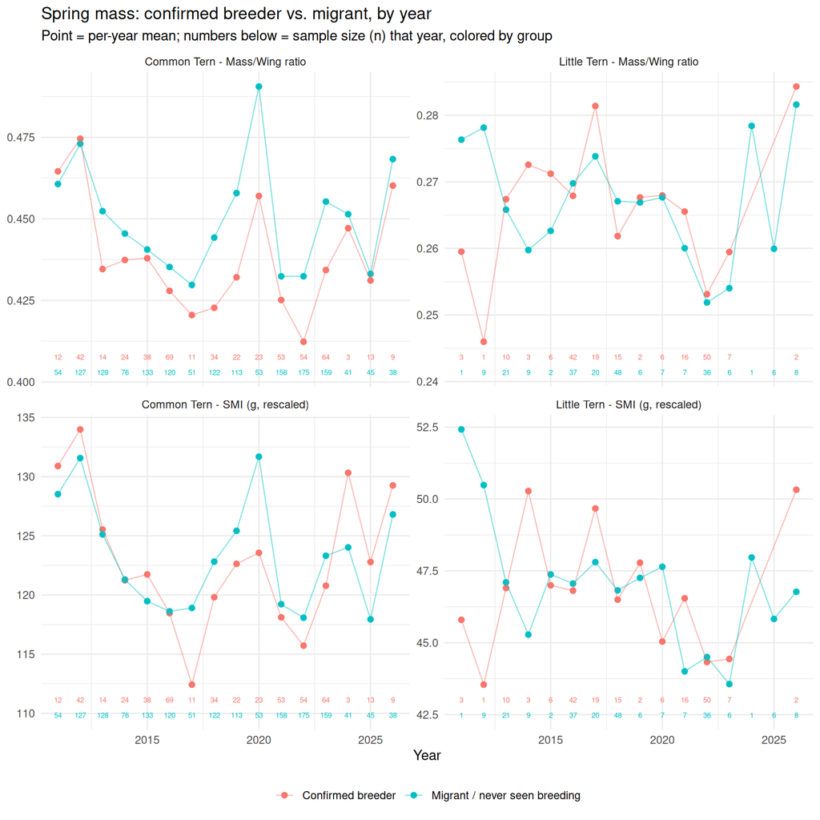

```r
panel_levels_spring <- c("Common Tern - Mass/Wing ratio", "Little Tern - Mass/Wing ratio",
                          "Common Tern - SMI (g, rescaled)", "Little Tern - SMI (g, rescaled)")

spring_long <- spring_adults %>%
  pivot_longer(cols = c(mass_ratio, smi), names_to = "metric", values_to = "value") %>%
  mutate(metric_label = relabel_metric(metric),
         panel_label = factor(paste(species_label, metric_label, sep = " - "), levels = panel_levels_spring))

spring_yearly <- spring_long %>%
  group_by(species_label, group, metric, metric_label, panel_label, year) %>%
  summarise(mean_value = mean(value), n = n(), .groups = "drop")

# Two groups' n-labels at the same y position would overlap (both plotted
# "below the point"), so each group gets its own row, stacked vertically
# and colored to match its line, rather than a single shared y_label.
label_pos_spring <- spring_yearly %>%
  group_by(panel_label) %>%
  mutate(panel_range = max(mean_value) - min(mean_value),
         y_label = min(mean_value) - if_else(group == "Confirmed breeder", 0.06, 0.12) * panel_range) %>%
  ungroup()

p_spring_groups <- ggplot(spring_yearly, aes(year, mean_value, color = group)) +
  geom_point(size = 1.8) +
  geom_line(linewidth = 0.4, alpha = 0.5) +
  geom_text(data = label_pos_spring, aes(y = y_label, label = n, color = group), size = 2, show.legend = FALSE) +
  facet_wrap(~panel_label, ncol = 2, scales = "free_y") +
  labs(title = "Spring mass: confirmed breeder vs. migrant, by year",
       subtitle = "Point = per-year mean; numbers below = sample size (n) that year, colored by group",
       y = NULL, x = "Year", color = NULL) +
  theme_minimal() +
  theme(legend.position = "bottom")
p_spring_groups
```

## 3.4 Significance test: does the group gap hold?

Two tests per species/metric: a pooled two-sample t-test (ignoring year), and a year-controlled model (`value ~ group + year`, holding year fixed) as a robustness check against the group difference being confounded by which years each group happens to have more/less data in.

```r
spring_group_tests <- bind_rows(lapply(c("mass_ratio", "smi"), function(met) {
  bind_rows(lapply(c("Common Tern", "Little Tern"), function(sp) {
    d <- spring_adults %>% filter(species_label == sp)
    breeder_v <- d[[met]][d$group == "Confirmed breeder"]
    migrant_v <- d[[met]][d$group == "Migrant / never seen breeding"]
    tt <- t.test(breeder_v, migrant_v)
    d2 <- d %>% mutate(year_f = factor(year))
    m <- lm(as.formula(paste0(met, " ~ group + year_f")), data = d2)
    co <- summary(m)$coefficients
    row <- co[grepl("^group", rownames(co)), , drop = FALSE]
    tibble(
      species_label = sp, metric = met,
      n_breeder = length(breeder_v), n_migrant = length(migrant_v),
      mean_breeder = round(mean(breeder_v), 4), mean_migrant = round(mean(migrant_v), 4),
      pooled_t_p = signif(tt$p.value, 3),
      year_controlled_effect = round(row[1, "Estimate"], 4),
      year_controlled_p = signif(row[1, "Pr(>|t|)"], 3)
    )
  }))
})) %>%
  mutate(metric = relabel_metric(metric)) %>%
  arrange(species_label, metric)

kable(spring_group_tests, digits = 4,
      caption = "Confirmed breeder vs. migrant: pooled t-test and year-controlled effect, by species/metric")
```

Confirmed breeder vs. migrant: pooled t-test and year-controlled effect, by species/metric

| species_label | metric | n_breeder | n_migrant | mean_breeder | mean_migrant | pooled_t_p | year_controlled_effect | year_controlled_p |
| --- | --- | --- | --- | --- | --- | --- | --- | --- |
| Common Tern | Mass/Wing ratio | 485 | 1593 | 0.4350 | 0.4479 | 0.0000 | 0.0125 | 0.000 |
| Common Tern | SMI (g, rescaled) | 485 | 1593 | 121.4537 | 122.7417 | 0.0593 | 0.9080 | 0.171 |
| Little Tern | Mass/Wing ratio | 182 | 224 | 0.2643 | 0.2655 | 0.5620 | -0.0007 | 0.735 |
| Little Tern | SMI (g, rescaled) | 182 | 224 | 46.3130 | 46.5566 | 0.5950 | -0.1969 | 0.675 |

## 3.5 Is the last year’s gap different from the historical gap?

```r
spring_lastyear_tests <- bind_rows(lapply(c("mass_ratio", "smi"), function(met) {
  bind_rows(lapply(c("Common Tern", "Little Tern"), function(sp) {
    d <- spring_adults %>% filter(species_label == sp)
    latest <- max(d$year)
    d <- d %>% mutate(is_last = factor(ifelse(year == latest, "last", "other"), levels = c("other", "last")))
    form <- as.formula(paste0(met, " ~ group * is_last"))
    m <- lm(form, data = d)
    co <- summary(m)$coefficients
    inter_name <- grep(":is_last", rownames(co), value = TRUE)
    if (length(inter_name) == 0) {
      tibble(species_label = sp, metric = met, latest_year = latest,
             interaction_p = NA_real_, note = "insufficient data to fit interaction")
    } else {
      tibble(species_label = sp, metric = met, latest_year = latest,
             interaction_p = signif(co[inter_name, "Pr(>|t|)"], 3), note = "")
    }
  }))
})) %>%
  mutate(metric = relabel_metric(metric)) %>%
  arrange(species_label, metric)

kable(spring_lastyear_tests, digits = 4,
      caption = "Does the breeder-vs-migrant gap in the most recent year differ from the gap in other years? (group x is_last_year interaction)")
```

Does the breeder-vs-migrant gap in the most recent year differ from the gap in other years? (group x is_last_year interaction)

| species_label | metric | latest_year | interaction_p | note |
| --- | --- | --- | --- | --- |
| Common Tern | Mass/Wing ratio | 2026 | 0.732 |  |
| Common Tern | SMI (g, rescaled) | 2026 | 0.447 |  |
| Little Tern | Mass/Wing ratio | 2026 | 0.833 |  |
| Little Tern | SMI (g, rescaled) | 2026 | 0.293 |  |

# 4 2. Spring: breeder mass over years

**Question**: does breeding-population adult mass decline over the years in spring?

**Population**: Common Tern uses the “Confirmed breeder” group from Section 1 (spring-caught, confirmed via a June/July sighting in any year) - the closest available breeding-population definition. **Little Tern has no meaningful breeder/non-breeder split** (issue #5 task 2 found no significant mass difference between the two, and Section 1 above confirms it again under normalization), so Little Tern uses **all** spring adults, unsplit - splitting an already-small sample here would add noise, not signal. SMI is fit **per group on its own data** here (unlike Section 1’s pooled reference), matching issues #6/#7/#8/#9’s convention for tracking a group’s own condition over time.

```r
ct_breeder_trend <- terns %>%
  filter(species_label == "Common Tern", is_adult, !is.na(Weight), !is.na(Wing), month %in% 3:5,
         ring_id %in% summer_ring_ids_anyyear) %>%
  mutate(mass_ratio = Weight / Wing) %>%
  compute_smi()

lt_adult_trend <- terns %>%
  filter(species_label == "Little Tern", is_adult, !is.na(Weight), !is.na(Wing), month %in% 3:5) %>%
  mutate(mass_ratio = Weight / Wing) %>%
  compute_smi()

spring_trend_pop <- bind_rows(ct_breeder_trend, lt_adult_trend)
res_spring_trend <- build_trend_outputs(spring_trend_pop, "Spring breeder mass over years")
```

## 4.1 Sample size

```r
kable(res_spring_trend$n_table, caption = "Sample size by year and species (Common Tern = confirmed breeders; Little Tern = all spring adults)")
```

Sample size by year and species (Common Tern = confirmed breeders; Little Tern = all spring adults)

| year | Common Tern | Little Tern |
| --- | --- | --- |
| 2011 | 12 | 4 |
| 2012 | 42 | 10 |
| 2013 | 14 | 31 |
| 2014 | 24 | 12 |
| 2015 | 38 | 8 |
| 2016 | 69 | 79 |
| 2017 | 11 | 39 |
| 2018 | 34 | 63 |
| 2019 | 22 | 8 |
| 2020 | 23 | 13 |
| 2021 | 53 | 23 |
| 2022 | 54 | 86 |
| 2023 | 64 | 13 |
| 2024 | 3 | 1 |
| 2025 | 13 | 6 |
| 2026 | 9 | 10 |

## 4.2 Plot

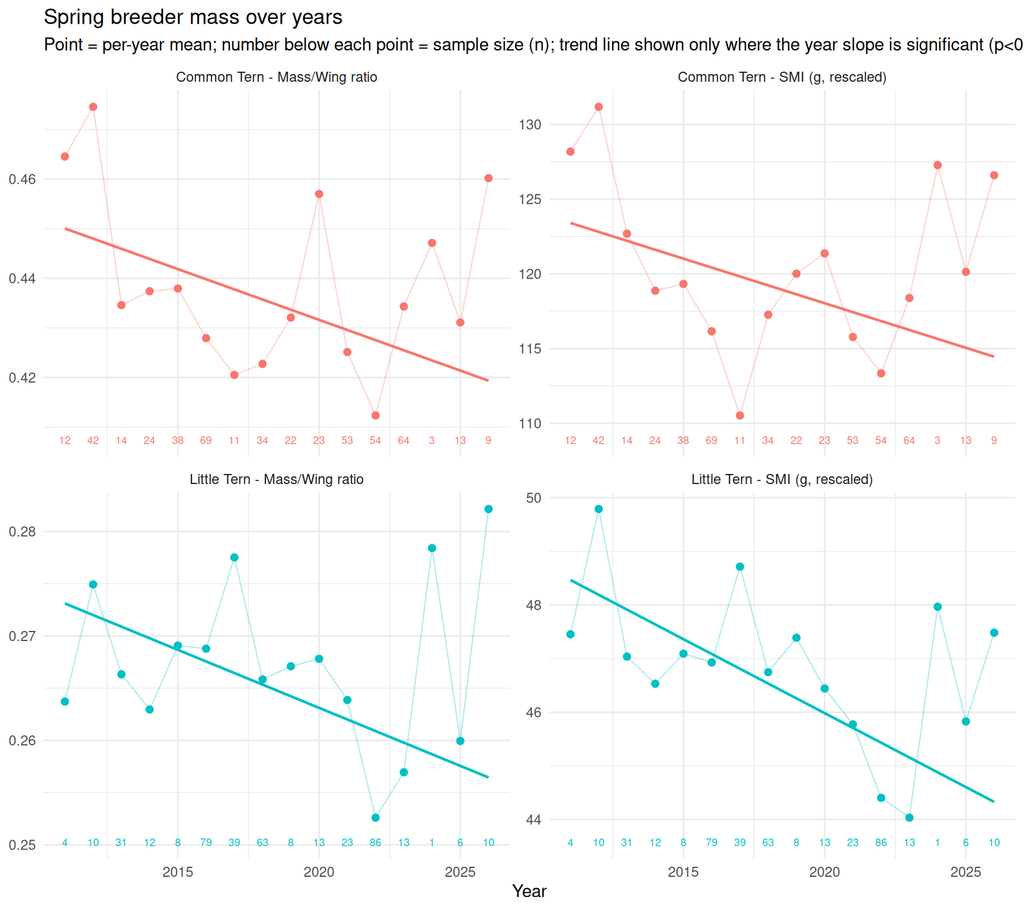

```r
res_spring_trend$plot
```

## 4.3 Significance test

```r
kable(res_spring_trend$trend_stats, digits = 4, caption = "value ~ year regression, spring breeder mass, by species/metric")
```

value ~ year regression, spring breeder mass, by species/metric

| species_label | n | n_years | slope_per_year | se | p_value | r_squared | metric |
| --- | --- | --- | --- | --- | --- | --- | --- |
| Common Tern | 485 | 16 | -0.0020 | 0.0004 | 0e+00 | 0.0508 | Mass/Wing ratio |
| Common Tern | 485 | 16 | -0.5967 | 0.1388 | 0e+00 | 0.0369 | SMI (g, rescaled) |
| Little Tern | 406 | 16 | -0.0011 | 0.0003 | 3e-04 | 0.0323 | Mass/Wing ratio |
| Little Tern | 406 | 16 | -0.2759 | 0.0640 | 0e+00 | 0.0439 | SMI (g, rescaled) |

## 4.4 Is the last year different from the historical trend?

```r
kable(res_spring_trend$lastyear %>% rename(species_label = label), digits = 4,
      caption = "Does the most recent year's mean deviate from what the linear year-trend predicts? (value ~ year + is_last_year)")
```

Does the most recent year’s mean deviate from what the linear year-trend predicts? (value ~ year + is_last_year)

| species_label | metric | latest_year | n_latest | n_other | mean_latest | trend_predicted | deviation | p_value |
| --- | --- | --- | --- | --- | --- | --- | --- | --- |
| Common Tern | Mass/Wing ratio | 2026 | 9 | 476 | 0.4602 | 0.4155 | 0.0447 | 0.0003 |
| Common Tern | SMI (g, rescaled) | 2026 | 9 | 476 | 126.6027 | 113.3101 | 13.2926 | 0.0018 |
| Little Tern | Mass/Wing ratio | 2026 | 10 | 396 | 0.2822 | 0.2520 | 0.0301 | 0.0000 |
| Little Tern | SMI (g, rescaled) | 2026 | 10 | 396 | 47.4830 | 43.7859 | 3.6970 | 0.0152 |

# 5 3. Summer: adult mass over years

**Question**: does adult mass change over the years in summer?

**Population**: adults captured directly in the colony during summer (Jun-Jul, new ringings + recaptures) - by construction all breeders, so no breeder/non-breeder split is needed (matches issue #8’s population).

```r
summer_adult_trend <- terns %>%
  filter(is_capture, !(Age %in% juvenile_ages), !is.na(Weight), !is.na(Wing), month %in% 6:7) %>%
  mutate(mass_ratio = Weight / Wing) %>%
  group_by(species_label) %>%
  group_modify(~ compute_smi(.x)) %>%
  ungroup()

res_summer_trend <- build_trend_outputs(summer_adult_trend, "Summer (Jun-Jul) adult mass over years")
```

## 5.1 Sample size

```r
kable(res_summer_trend$n_table, caption = "Sample size by year and species (summer-caught adults)")
```

Sample size by year and species (summer-caught adults)

| year | Common Tern | Little Tern |
| --- | --- | --- |
| 2010 | 62 | 63 |
| 2011 | 121 | 21 |
| 2012 | 79 | 27 |
| 2013 | 38 | 37 |
| 2014 | 53 | 57 |
| 2015 | 51 | 71 |
| 2016 | 117 | 71 |
| 2017 | 119 | 58 |
| 2018 | 45 | 48 |
| 2019 | 76 | 44 |
| 2020 | 204 | 62 |
| 2021 | 58 | 14 |
| 2022 | 86 | 51 |
| 2023 | 48 | 17 |
| 2024 | 44 | 11 |
| 2026 | 82 | 23 |
| 2025 | 0 | 8 |

## 5.2 Plot

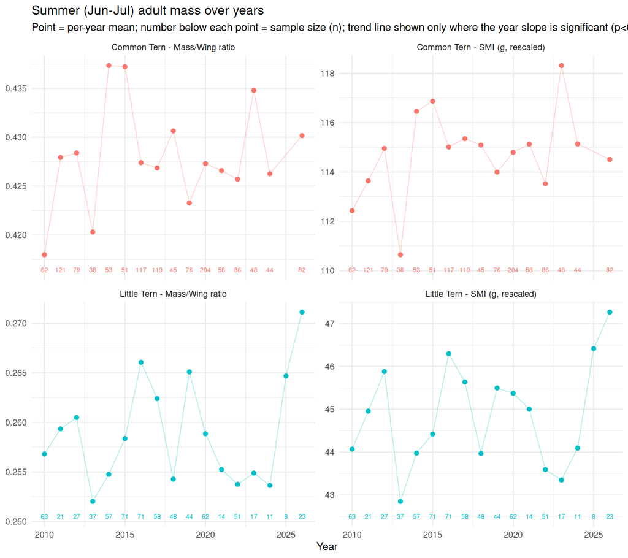

```r
res_summer_trend$plot
```

## 5.3 Significance test

```r
kable(res_summer_trend$trend_stats, digits = 4, caption = "value ~ year regression, summer adult mass, by species/metric")
```

value ~ year regression, summer adult mass, by species/metric

| species_label | n | n_years | slope_per_year | se | p_value | r_squared | metric |
| --- | --- | --- | --- | --- | --- | --- | --- |
| Common Tern | 1283 | 16 | 0.0002 | 0.0002 | 0.452 | 0.0004 | Mass/Wing ratio |
| Common Tern | 1283 | 16 | 0.0890 | 0.0673 | 0.186 | 0.0014 | SMI (g, rescaled) |
| Little Tern | 683 | 17 | 0.0002 | 0.0002 | 0.194 | 0.0025 | Mass/Wing ratio |
| Little Tern | 683 | 17 | 0.0661 | 0.0405 | 0.103 | 0.0039 | SMI (g, rescaled) |

## 5.4 Is the last year different from the historical trend?

```r
kable(res_summer_trend$lastyear %>% rename(species_label = label), digits = 4,
      caption = "Does the most recent year's mean deviate from what the linear year-trend predicts? (value ~ year + is_last_year)")
```

Does the most recent year’s mean deviate from what the linear year-trend predicts? (value ~ year + is_last_year)

| species_label | metric | latest_year | n_latest | n_other | mean_latest | trend_predicted | deviation | p_value |
| --- | --- | --- | --- | --- | --- | --- | --- | --- |
| Common Tern | Mass/Wing ratio | 2026 | 82 | 1201 | 0.4302 | 0.4285 | 0.0017 | 0.6970 |
| Common Tern | SMI (g, rescaled) | 2026 | 82 | 1201 | 114.5076 | 115.8294 | -1.3219 | 0.3530 |
| Little Tern | Mass/Wing ratio | 2026 | 23 | 660 | 0.2711 | 0.2587 | 0.0124 | 0.0079 |
| Little Tern | SMI (g, rescaled) | 2026 | 23 | 660 | 47.2696 | 44.9446 | 2.3249 | 0.0231 |

# 6 4. Within-season trajectory

**Question**: within a season, does mass change, and is that pattern itself changing over the years or in the most recent year(s)?

This reuses issue #10’s `scripts/09_summer_adult_within_season.Rmd` results directly (Jun-Jul window - August can include passage migrants as well as the local breeding population, so it’s excluded here), filtered to the two normalized metrics only. Full detail, including the raw-mass comparison and the Jun-Aug window, is in that script/issue.

```r
within_pooled <- read.csv(file.path(proc_dir, "summer_adult_within_season_pooled_stats_normalized.csv")) %>%
  filter(window == "Jun-Jul", metric != "Raw mass (g)")
within_interaction <- read.csv(file.path(proc_dir, "summer_adult_within_season_interaction_stats_normalized.csv")) %>%
  filter(window == "Jun-Jul", metric != "Raw mass (g)")
within_peryear <- read.csv(file.path(proc_dir, "summer_adult_within_season_junjul_peryear_slopes.csv")) %>%
  filter(metric != "Raw mass (g)")
within_recent <- read.csv(file.path(proc_dir, "summer_adult_within_season_junjul_recent_vs_historical.csv")) %>%
  filter(metric != "Raw mass (g)")
```

## 6.1 Sample size

```r
kable(within_pooled %>% select(species_label, metric, n, n_years),
      caption = "Sample size, Jun-Jul within-season population, by species/metric")
```

Sample size, Jun-Jul within-season population, by species/metric

| species_label | metric | n | n_years |
| --- | --- | --- | --- |
| Common Tern | Mass/Wing ratio | 1283 | 16 |
| Common Tern | SMI (g, rescaled) | 1283 | 16 |
| Little Tern | Mass/Wing ratio | 683 | 17 |
| Little Tern | SMI (g, rescaled) | 683 | 17 |

## 6.2 Plot

Same population and method as issue #10’s within-season plots (per-year trend lines colored by year, latest year excluded from that layer and shown separately as the thick black line - see issue #10 for why), filtered to the two normalized metrics only:

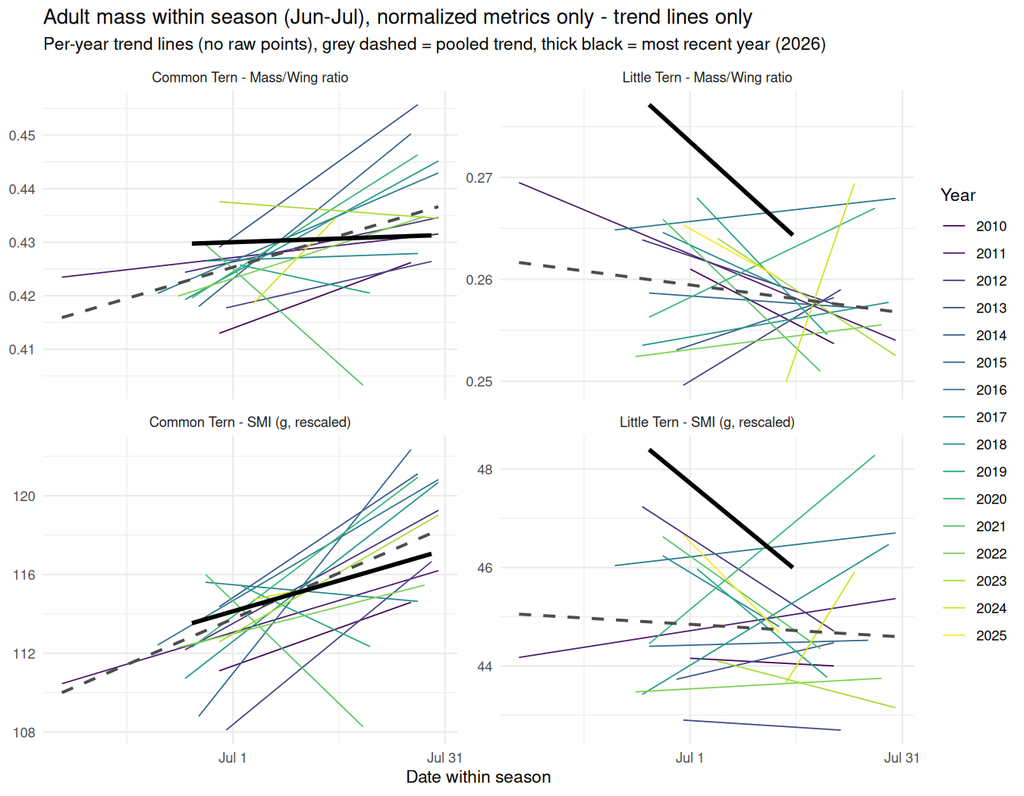

Within-season trajectory, Jun-Jul, normalized metrics only

## 6.3 Significance test: does mass change within the season, in general?

```r
kable(within_pooled %>% select(-window), digits = 4,
      caption = "Pooled value ~ day_of_season, Jun-Jul, normalized metrics")
```

Pooled value ~ day_of_season, Jun-Jul, normalized metrics

| species_label | n | n_years | slope | se | p_value | r_squared | metric |
| --- | --- | --- | --- | --- | --- | --- | --- |
| Common Tern | 1283 | 16 | 0.0004 | 0.0001 | 0.000 | 0.0205 | Mass/Wing ratio |
| Common Tern | 1283 | 16 | 0.1500 | 0.0243 | 0.000 | 0.0288 | SMI (g, rescaled) |
| Little Tern | 683 | 17 | -0.0001 | 0.0001 | 0.237 | 0.0021 | Mass/Wing ratio |
| Little Tern | 683 | 17 | -0.0083 | 0.0163 | 0.613 | 0.0004 | SMI (g, rescaled) |

```r
kable(within_interaction %>% select(-window),
      caption = "day_of_season x year interaction - does the within-season pattern hold every year, or vary?")
```

day_of_season x year interaction - does the within-season pattern hold every year, or vary?

| species_label | n | n_years | interaction_p | metric |
| --- | --- | --- | --- | --- |
| Common Tern | 1283 | 16 | 0.115 | Mass/Wing ratio |
| Common Tern | 1283 | 16 | 0.180 | SMI (g, rescaled) |
| Little Tern | 683 | 17 | 0.730 | Mass/Wing ratio |
| Little Tern | 683 | 17 | 0.892 | SMI (g, rescaled) |

## 6.4 Per-year within-season slope

```r
kable(within_peryear, digits = 4,
      caption = "Per-year value ~ day_of_season slope, Jun-Jul (years with n >= 5 only)")
```

Per-year value ~ day_of_season slope, Jun-Jul (years with n >= 5 only)

| species_label | year | n | slope | se | p_value | metric |
| --- | --- | --- | --- | --- | --- | --- |
| Common Tern | 2010 | 62 | 0.0005 | 0.0005 | 0.3510 | Mass/Wing ratio |
| Common Tern | 2011 | 121 | 0.0001 | 0.0002 | 0.4290 | Mass/Wing ratio |
| Common Tern | 2012 | 79 | 0.0003 | 0.0003 | 0.3390 | Mass/Wing ratio |
| Common Tern | 2013 | 38 | 0.0003 | 0.0006 | 0.6420 | Mass/Wing ratio |
| Common Tern | 2014 | 53 | 0.0009 | 0.0005 | 0.0839 | Mass/Wing ratio |
| Common Tern | 2015 | 51 | 0.0010 | 0.0004 | 0.0148 | Mass/Wing ratio |
| Common Tern | 2016 | 117 | 0.0005 | 0.0002 | 0.0021 | Mass/Wing ratio |
| Common Tern | 2017 | 119 | 0.0000 | 0.0004 | 0.9080 | Mass/Wing ratio |
| Common Tern | 2018 | 45 | 0.0007 | 0.0004 | 0.0760 | Mass/Wing ratio |
| Common Tern | 2019 | 76 | -0.0003 | 0.0005 | 0.5950 | Mass/Wing ratio |
| Common Tern | 2020 | 204 | 0.0008 | 0.0002 | 0.0001 | Mass/Wing ratio |
| Common Tern | 2021 | 58 | -0.0011 | 0.0005 | 0.0169 | Mass/Wing ratio |
| Common Tern | 2022 | 86 | 0.0004 | 0.0003 | 0.1250 | Mass/Wing ratio |
| Common Tern | 2023 | 48 | -0.0001 | 0.0005 | 0.8590 | Mass/Wing ratio |
| Common Tern | 2024 | 44 | 0.0013 | 0.0008 | 0.0986 | Mass/Wing ratio |
| Common Tern | 2026 | 82 | 0.0000 | 0.0004 | 0.9170 | Mass/Wing ratio |
| Common Tern | 2010 | 62 | 0.1243 | 0.1509 | 0.4130 | SMI (g, rescaled) |
| Common Tern | 2011 | 121 | 0.1044 | 0.0647 | 0.1090 | SMI (g, rescaled) |
| Common Tern | 2012 | 79 | 0.1913 | 0.0967 | 0.0515 | SMI (g, rescaled) |
| Common Tern | 2013 | 38 | 0.2852 | 0.1993 | 0.1610 | SMI (g, rescaled) |
| Common Tern | 2014 | 53 | 0.2329 | 0.1979 | 0.2450 | SMI (g, rescaled) |
| Common Tern | 2015 | 51 | 0.4370 | 0.1407 | 0.0031 | SMI (g, rescaled) |
| Common Tern | 2016 | 117 | 0.2049 | 0.0627 | 0.0014 | SMI (g, rescaled) |
| Common Tern | 2017 | 119 | -0.0313 | 0.1313 | 0.8120 | SMI (g, rescaled) |
| Common Tern | 2018 | 45 | 0.2692 | 0.1203 | 0.0305 | SMI (g, rescaled) |
| Common Tern | 2019 | 76 | -0.1643 | 0.1611 | 0.3110 | SMI (g, rescaled) |
| Common Tern | 2020 | 204 | 0.2615 | 0.0679 | 0.0002 | SMI (g, rescaled) |
| Common Tern | 2021 | 58 | -0.3362 | 0.1678 | 0.0500 | SMI (g, rescaled) |
| Common Tern | 2022 | 86 | 0.0881 | 0.0877 | 0.3180 | SMI (g, rescaled) |
| Common Tern | 2023 | 48 | 0.2010 | 0.1688 | 0.2400 | SMI (g, rescaled) |
| Common Tern | 2024 | 44 | 0.0678 | 0.2236 | 0.7630 | SMI (g, rescaled) |
| Common Tern | 2026 | 82 | 0.1007 | 0.1396 | 0.4720 | SMI (g, rescaled) |
| Little Tern | 2010 | 63 | -0.0003 | 0.0003 | 0.2740 | Mass/Wing ratio |
| Little Tern | 2011 | 21 | -0.0003 | 0.0004 | 0.4770 | Mass/Wing ratio |
| Little Tern | 2012 | 27 | -0.0002 | 0.0003 | 0.5000 | Mass/Wing ratio |
| Little Tern | 2013 | 37 | 0.0004 | 0.0004 | 0.3530 | Mass/Wing ratio |
| Little Tern | 2014 | 57 | 0.0002 | 0.0003 | 0.4540 | Mass/Wing ratio |
| Little Tern | 2015 | 71 | 0.0000 | 0.0002 | 0.8290 | Mass/Wing ratio |
| Little Tern | 2016 | 71 | 0.0001 | 0.0002 | 0.7210 | Mass/Wing ratio |
| Little Tern | 2017 | 58 | -0.0003 | 0.0004 | 0.4230 | Mass/Wing ratio |
| Little Tern | 2018 | 48 | 0.0001 | 0.0003 | 0.6950 | Mass/Wing ratio |
| Little Tern | 2019 | 44 | -0.0007 | 0.0005 | 0.1870 | Mass/Wing ratio |
| Little Tern | 2020 | 62 | 0.0003 | 0.0003 | 0.3120 | Mass/Wing ratio |
| Little Tern | 2021 | 14 | -0.0006 | 0.0005 | 0.2130 | Mass/Wing ratio |
| Little Tern | 2022 | 51 | 0.0001 | 0.0002 | 0.7170 | Mass/Wing ratio |
| Little Tern | 2023 | 17 | -0.0004 | 0.0004 | 0.3090 | Mass/Wing ratio |
| Little Tern | 2024 | 11 | 0.0020 | 0.0013 | 0.1810 | Mass/Wing ratio |
| Little Tern | 2025 | 8 | -0.0004 | 0.0017 | 0.8320 | Mass/Wing ratio |
| Little Tern | 2026 | 23 | -0.0006 | 0.0010 | 0.5590 | Mass/Wing ratio |
| Little Tern | 2010 | 63 | -0.0074 | 0.0625 | 0.9060 | SMI (g, rescaled) |
| Little Tern | 2011 | 21 | 0.0217 | 0.0785 | 0.7850 | SMI (g, rescaled) |
| Little Tern | 2012 | 27 | -0.0904 | 0.0612 | 0.1520 | SMI (g, rescaled) |
| Little Tern | 2013 | 37 | -0.0089 | 0.0967 | 0.9280 | SMI (g, rescaled) |
| Little Tern | 2014 | 57 | 0.0323 | 0.0678 | 0.6350 | SMI (g, rescaled) |
| Little Tern | 2015 | 71 | 0.0038 | 0.0462 | 0.9340 | SMI (g, rescaled) |
| Little Tern | 2016 | 71 | 0.0162 | 0.0469 | 0.7320 | SMI (g, rescaled) |
| Little Tern | 2017 | 58 | -0.0846 | 0.0874 | 0.3370 | SMI (g, rescaled) |
| Little Tern | 2018 | 48 | 0.0846 | 0.0722 | 0.2470 | SMI (g, rescaled) |
| Little Tern | 2019 | 44 | -0.1159 | 0.1105 | 0.3000 | SMI (g, rescaled) |
| Little Tern | 2020 | 62 | 0.1161 | 0.0697 | 0.1010 | SMI (g, rescaled) |
| Little Tern | 2021 | 14 | -0.0989 | 0.1340 | 0.4750 | SMI (g, rescaled) |
| Little Tern | 2022 | 51 | 0.0077 | 0.0606 | 0.8990 | SMI (g, rescaled) |
| Little Tern | 2023 | 17 | -0.0364 | 0.0829 | 0.6670 | SMI (g, rescaled) |
| Little Tern | 2024 | 11 | 0.2245 | 0.3159 | 0.4950 | SMI (g, rescaled) |
| Little Tern | 2025 | 8 | -0.1420 | 0.3937 | 0.7310 | SMI (g, rescaled) |
| Little Tern | 2026 | 23 | -0.1143 | 0.2010 | 0.5760 | SMI (g, rescaled) |

```r
kable(within_peryear %>% group_by(species_label, metric) %>%
        summarise(n_years = n(), n_negative = sum(slope < 0), n_positive = sum(slope > 0), .groups = "drop"),
      caption = "Sign of the per-year slope")
```

Sign of the per-year slope

| species_label | metric | n_years | n_negative | n_positive |
| --- | --- | --- | --- | --- |
| Common Tern | Mass/Wing ratio | 16 | 3 | 11 |
| Common Tern | SMI (g, rescaled) | 16 | 3 | 13 |
| Little Tern | Mass/Wing ratio | 17 | 9 | 7 |
| Little Tern | SMI (g, rescaled) | 17 | 9 | 8 |

## 6.5 Is the last year (or last few years) different from the rest?

```r
kable(within_recent, digits = 4,
      caption = "Recent-years vs. historical within-season slope, Jun-Jul, normalized metrics (day_of_season x group interaction test)")
```

Recent-years vs. historical within-season slope, Jun-Jul, normalized metrics (day_of_season x group interaction test)

| comparison | metric | n_recent | n_other | slope_other | slope_recent | slope_diff | p_value |
| --- | --- | --- | --- | --- | --- | --- | --- |
| Common Tern: 2026 vs. all other years | Mass/Wing ratio | 82 | 1201 | 0.0004 | 0.0000 | -0.0004 | 0.3680 |
| Common Tern: 2026 vs. all other years | SMI (g, rescaled) | 82 | 1201 | 0.1521 | 0.1007 | -0.0514 | 0.6930 |
| Common Tern: last 3 yrs w/ data (2023, 2024, 2026) vs. earlier | Mass/Wing ratio | 174 | 1109 | 0.0004 | 0.0002 | -0.0002 | 0.3130 |
| Common Tern: last 3 yrs w/ data (2023, 2024, 2026) vs. earlier | SMI (g, rescaled) | 174 | 1109 | 0.1481 | 0.1512 | 0.0031 | 0.9650 |
| Little Tern: 2026 vs. all other years | Mass/Wing ratio | 23 | 660 | -0.0001 | -0.0006 | -0.0005 | 0.3940 |
| Little Tern: 2026 vs. all other years | SMI (g, rescaled) | 23 | 660 | -0.0054 | -0.1144 | -0.1090 | 0.4290 |
| Little Tern: last 3 yrs w/ data (2024, 2025, 2026) vs. earlier | Mass/Wing ratio | 42 | 641 | -0.0001 | -0.0007 | -0.0006 | 0.1090 |
| Little Tern: last 3 yrs w/ data (2024, 2025, 2026) vs. earlier | SMI (g, rescaled) | 42 | 641 | -0.0037 | -0.1445 | -0.1408 | 0.0985 |

No significant difference for either species, under either normalized metric, under either definition of “recent” (all p > 0.09) - see issue #10 for the full reasoning behind this test design.

# 7 5. Chicks: mass over years

**Question**: does chick mass decline over the years?

**Population**: this-year juveniles (age 3), Jun-Aug, new ringings + recaptures (matches issue #9’s population).

```r
chick_trend <- terns %>%
  filter(is_capture, Age == 3, !is.na(Weight), !is.na(Wing), month %in% 6:8) %>%
  mutate(mass_ratio = Weight / Wing) %>%
  group_by(species_label) %>%
  group_modify(~ compute_smi(.x)) %>%
  ungroup()

res_chick_trend <- build_trend_outputs(chick_trend, "Summer chick mass over years")
```

## 7.1 Sample size

```r
kable(res_chick_trend$n_table, caption = "Sample size by year and species (Jun-Aug chicks)")
```

Sample size by year and species (Jun-Aug chicks)

| year | Common Tern | Little Tern |
| --- | --- | --- |
| 2010 | 31 | 19 |
| 2011 | 97 | 37 |
| 2012 | 103 | 107 |
| 2013 | 59 | 7 |
| 2014 | 46 | 8 |
| 2015 | 120 | 12 |
| 2016 | 12 | 6 |
| 2017 | 11 | 0 |
| 2018 | 124 | 8 |
| 2019 | 137 | 0 |
| 2020 | 171 | 0 |
| 2021 | 66 | 3 |
| 2022 | 80 | 11 |
| 2023 | 129 | 0 |
| 2024 | 33 | 1 |
| 2025 | 15 | 1 |
| 2026 | 40 | 0 |

## 7.2 Plot

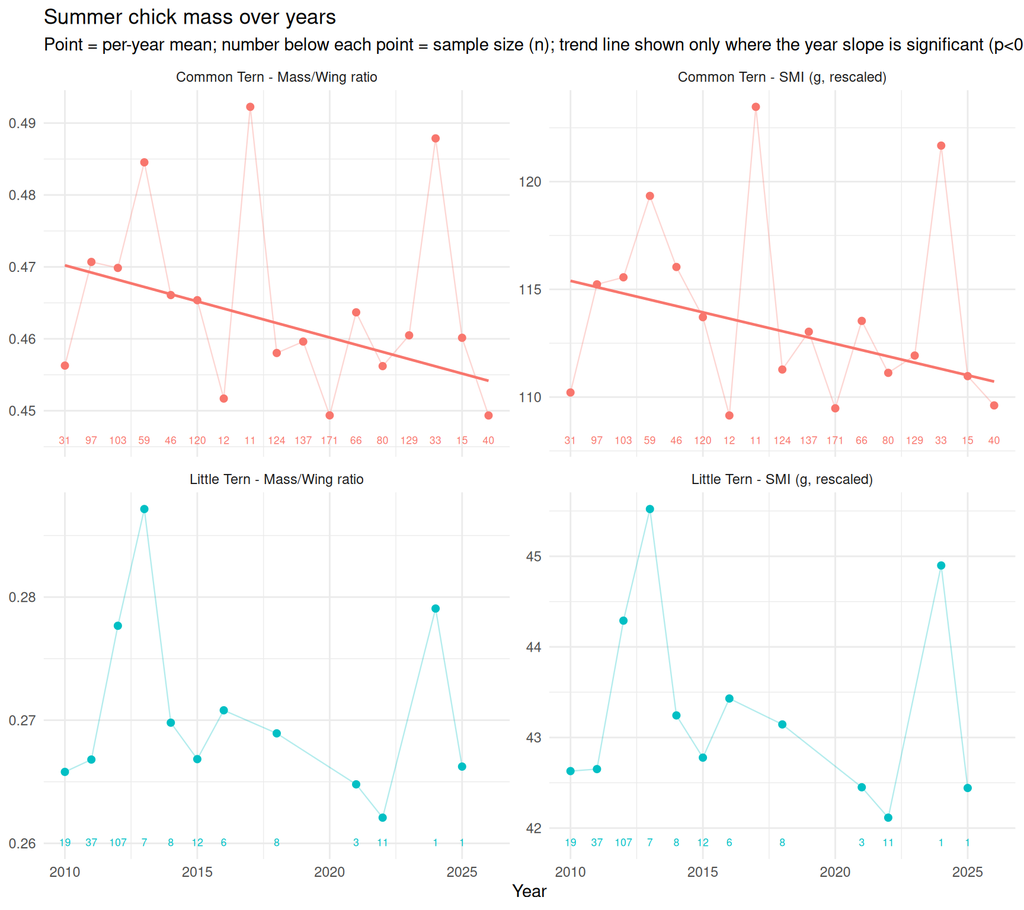

```r
res_chick_trend$plot
```

## 7.3 Significance test

```r
kable(res_chick_trend$trend_stats, digits = 4, caption = "value ~ year regression, chick mass, by species/metric")
```

value ~ year regression, chick mass, by species/metric

| species_label | n | n_years | slope_per_year | se | p_value | r_squared | metric |
| --- | --- | --- | --- | --- | --- | --- | --- |
| Common Tern | 1274 | 17 | -0.0010 | 0.0003 | 0.0005 | 0.0095 | Mass/Wing ratio |
| Common Tern | 1274 | 17 | -0.2921 | 0.0784 | 0.0002 | 0.0108 | SMI (g, rescaled) |
| Little Tern | 220 | 12 | -0.0006 | 0.0006 | 0.2970 | 0.0050 | Mass/Wing ratio |
| Little Tern | 220 | 12 | -0.0798 | 0.0906 | 0.3790 | 0.0035 | SMI (g, rescaled) |

## 7.4 Is the last year different from the historical trend?

```r
kable(res_chick_trend$lastyear %>% rename(species_label = label), digits = 4,
      caption = "Does the most recent year's mean deviate from what the linear year-trend predicts? (value ~ year + is_last_year)")
```

Does the most recent year’s mean deviate from what the linear year-trend predicts? (value ~ year + is_last_year)

| species_label | metric | latest_year | n_latest | n_other | mean_latest | trend_predicted | deviation | p_value |
| --- | --- | --- | --- | --- | --- | --- | --- | --- |
| Common Tern | Mass/Wing ratio | 2026 | 40 | 1234 | 0.4493 | 0.4550 | -0.0056 | 0.461 |
| Common Tern | SMI (g, rescaled) | 2026 | 40 | 1234 | 109.6122 | 110.9006 | -1.2884 | 0.535 |
| Little Tern | Mass/Wing ratio | 2025 | 1 | 219 | 0.2662 | 0.2652 | 0.0011 | 0.970 |
| Little Tern | SMI (g, rescaled) | 2025 | 1 | 219 | 42.4427 | 42.6410 | -0.1983 | 0.963 |

Little Tern’s “last year” here is **2025, not 2026** - there is zero Little Tern chick weight data in 2026, and only n=1 in 2025 (see issue #9’s caveat) - this deviation test is not meaningful for Little Tern and is included only for completeness.

# 8 Save outputs

```r
write.csv(spring_group_tests, file.path(proc_dir, "mass_summary_spring_breeder_vs_migrant_tests.csv"), row.names = FALSE)
write.csv(spring_lastyear_tests, file.path(proc_dir, "mass_summary_spring_breeder_vs_migrant_lastyear.csv"), row.names = FALSE)
write.csv(res_spring_trend$trend_stats, file.path(proc_dir, "mass_summary_spring_breeder_trend_stats.csv"), row.names = FALSE)
write.csv(res_spring_trend$lastyear, file.path(proc_dir, "mass_summary_spring_breeder_trend_lastyear.csv"), row.names = FALSE)
write.csv(res_summer_trend$trend_stats, file.path(proc_dir, "mass_summary_summer_adult_trend_stats.csv"), row.names = FALSE)
write.csv(res_summer_trend$lastyear, file.path(proc_dir, "mass_summary_summer_adult_trend_lastyear.csv"), row.names = FALSE)
write.csv(res_chick_trend$trend_stats, file.path(proc_dir, "mass_summary_chick_trend_stats.csv"), row.names = FALSE)
write.csv(res_chick_trend$lastyear, file.path(proc_dir, "mass_summary_chick_trend_lastyear.csv"), row.names = FALSE)
cat("Wrote 8 CSVs to", proc_dir, "with the mass_summary_ prefix\n")
```

```
## Wrote 8 CSVs to ../data_processed with the mass_summary_ prefix
```